# Tarea 2

Isabel Sutil Martin

23/9/2021

# Ejercicio 1. Simulando variables aleatorias discretas.

**Apartado 1:** La variable aleatoria discreta $X1$ tiene esta tabla de densidad de probabilidad (es la variable que se usa como ejemplo en la Sesión ):
$$\begin{array}{|c|c|c|c|c|c|c|}
\hline
\text{valor de }X1 & 0 & 1 & 2 & 3 \\
\hline
\text{Probabilidad de ese valor }P(X = x_i) & \dfrac{64}{125} &
\dfrac{48}{125}& \dfrac{12}{125} & \dfrac{1}{125}\rule{0mm}{6mm} \\[3mm]
\hline
\end{array}$$
Calcula la media y la varianza teóricas de esta variable.

Importamos todas las librerias

```r
library(tidyverse)
library(haven)
library(nycflights13)
library(GGally)
x1 = c(0:3)
probabilidad = c(64/125, 48/125, 12/125, 1/125)


(media = sum(x1*probabilidad))
```

```
## [1] 0.6
```

```r
(varianza = sum((x1-media)^2*probabilidad))
```

```
## [1] 0.48
```

**Apartado 2:** Combina `sample` con `replicate` para simular cien mil muestras de tamaño 10 de esta variable $X1$. Estudia la distribución de las medias muestrales como hemos hecho en ejemplos previos, ilustrando con gráficas la distribución de esas medias muestrales. Cambia después el tamaño de la muestra a 30 y repite el análisis.

Analisis tamaño 10

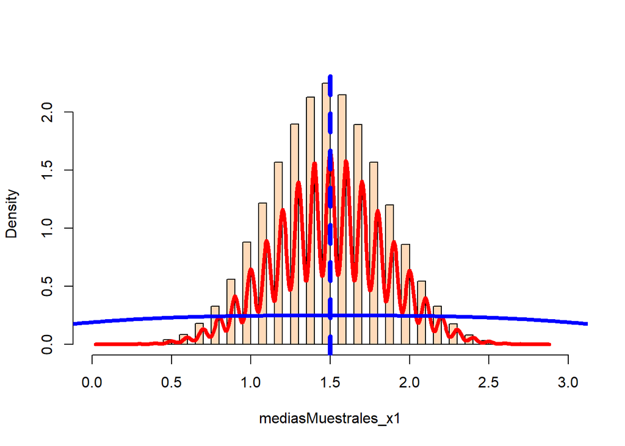

```r
mediasMuestrales_x1 = replicate(100000, {
  muestra = sample(x1,10, replace = TRUE)
  mean(muestra)
})

# Representación gráfica de la distribución de las medias muestrales

hist(mediasMuestrales_x1, breaks = 40, main="",
     col="peachpuff", probability = TRUE, xlim=range(x1))
    lines(density(mediasMuestrales_x1), lwd=4, col="red")
    lines(density(x1), lwd=4, col="blue")
    abline(v = mean(x1), lty=2, lwd=5, col="blue")
```

Analisis tamaño 30

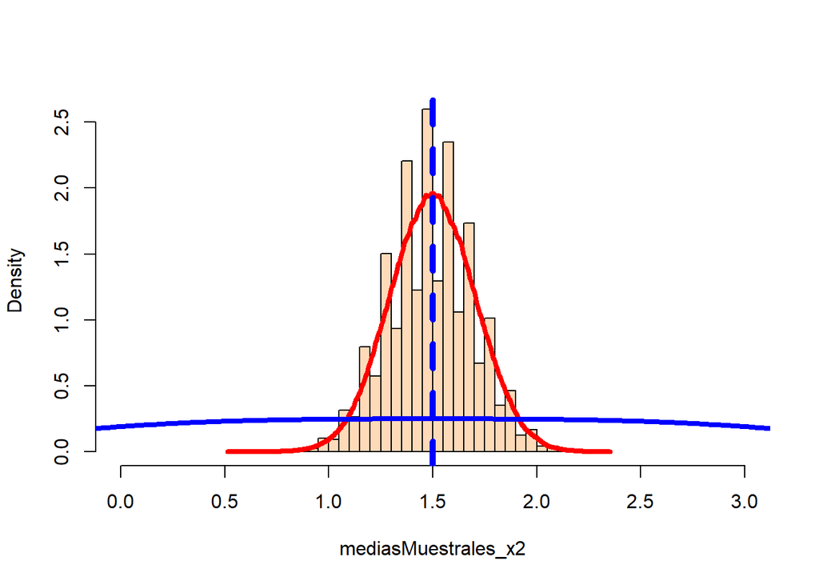

```r
mediasMuestrales_x2 = replicate(100000, {
  muestra = sample(x1,30, replace = TRUE)
  mean(muestra)
})

# Representación gráfica de la distribución de las medias muestrales

hist(mediasMuestrales_x2, breaks = 40, main="",
     col="peachpuff", probability = TRUE, xlim=range(x1))
    lines(density(mediasMuestrales_x2), lwd=4, col="red")
    lines(density(x1), lwd=4, col="blue")
    abline(v = mean(x1), lty=2, lwd=5, col="blue")
```

**Apartado 3:** La variable aleatoria discreta $X2$ tiene esta tabla de densidad de probabilidad:
$$\begin{array}{|c|c|c|c|c|c|}
\hline
\text{valor de }X2 & 0 & 1 & 2 \\
\hline
\text{Probabilidad de ese valor }P(X = x_i) & \dfrac{1}{2} &
\dfrac{1}{4}& \dfrac{1}{4}\rule{0mm}{6mm} \\[3mm]
\hline
\end{array}$$
Suponemos que $X1$ y $X2$ son independientes. ¿Qué valores puede tomar la suma $X1 + X2$? ¿Cuál es su tabla de probabilidad?

```r
x2 = c(0:2)
probabilidad2 = c(1/2, 1/4, 1/4)


(media = sum(x1*probabilidad))
```

```
## [1] 0.6
```

```r
(varianza = sum((x1-media)^2*probabilidad))
```

```
## [1] 0.48
```

```r
#Valores de la suma

#Prob de la suma de 0
p0 = probabilidad[1]*probabilidad2[1]
#Prob de la suma de 1
p1 = probabilidad[2]*probabilidad2[1] + probabilidad[1]*probabilidad2[2]
#Prob de la suma de 2
p2 = probabilidad[3]*probabilidad2[1] + probabilidad[2]*probabilidad2[2] + probabilidad[1]*probabilidad2[3]
#Prob de la suma de 3
p3 = probabilidad[4]*probabilidad2[1] + probabilidad[2]*probabilidad2[3] + probabilidad[3]*probabilidad2[2]
#Prob de la suma de 4
p4 = probabilidad[4]*probabilidad2[2] + probabilidad[3]*probabilidad2[3]
#Prob de la suma de 5
p5 = probabilidad[4]*probabilidad2[3]

tabla_prob = matrix(c(p0, p1, p2, p3, p4, p5), nrow = 1)
colnames(tabla_prob) =  c("Y0", "Y1", "Y2", "Y3", "Y4", "Y5")
tabla_prob
```

```
##         Y0   Y1    Y2    Y3    Y4    Y5
## [1,] 0.256 0.32 0.272 0.124 0.026 0.002
```

**Apartado 4:** Calcula la media teórica de la suma $X_1 + X_2$. Después usa `sample` y `replicate` para simular cien mil *valores* de esta variable suma. Calcula la media de esos valores. *Advertencia:* no es el mismo tipo de análisis que hemos hecho en el segundo apartado.

```r
vect_suma = c(0:5)

#media teorica
(media_teorica = sum(vect_suma* tabla_prob))
```

```
## [1] 1.35
```

```r
#generamos cien mil valores
valores = replicate(100000, {
  valor = sample(vect_suma, 1, prob = c(p0, p1, p2, p3, p4, p5))
})

#media de valores
(media_valores = mean(valores))
```

```
## [1] 1.35576
```

# Ejercicio 2. Datos limpios

- Descarga el fichero de este enlace

https://gist.githubusercontent.com/fernandosansegundo/471b4887737cfcec7e9cf28631f2e21e/raw/b3944599d02df494f5903740db5acac9da35bc6f/testResults.csv

- Este fichero contiene las notas de los alumnos de una clase, que hicieron dos tests cada semana durante cinco semanas. La tabla de datos no cumple los principios de *tidy data* que hemos visto en clase. Tu tarea en este ejercicio es explicar por qué no se cumplen y obtener una tabla de datos limpios con la misma información usando *tidyR*.  
  **Indicación:** lee la ayuda de la función `separate` de *tidyR*.

```r
csv_0 = read_csv("testResults.csv")
(csv_0)
```

```
## # A tibble: 200 x 9
##    name           id gender_age test_number week1 week2 week3 week4 week5
##    <chr>       <dbl> <chr>            <dbl> <dbl> <dbl> <dbl> <dbl> <dbl>
##  1 Jacob         108 m_20                 1     8     5     7     5     6
##  2 Jacob         108 m_20                 2     2     2     4     0     3
##  3 Michael       490 m_19                 1    10     0     5     4     0
##  4 Michael       490 m_19                 2     9    10     8    10     9
##  5 Matthew       424 m_18                 1     6     0     0     1    10
##  6 Matthew       424 m_18                 2     3     4     2     5     8
##  7 Joshua        734 m_17                 1    10     2     2     0     6
##  8 Joshua        734 m_17                 2    10     0     6     8     9
##  9 Christopher   928 m_20                 1     5     2     0     0     0
## 10 Christopher   928 m_20                 2     9     9     3    10     4
## # ... with 190 more rows
```

```r
# una columna 2 variables en 1

csv_1= csv_0 %>%
  separate(col  =  gender_age, into =  c("gender", "age"), sep  =  "_", convert = TRUE)

csv_1
```

```
## # A tibble: 200 x 10
##    name           id gender   age test_number week1 week2 week3 week4 week5
##    <chr>       <dbl> <chr>  <int>       <dbl> <dbl> <dbl> <dbl> <dbl> <dbl>
##  1 Jacob         108 m         20           1     8     5     7     5     6
##  2 Jacob         108 m         20           2     2     2     4     0     3
##  3 Michael       490 m         19           1    10     0     5     4     0
##  4 Michael       490 m         19           2     9    10     8    10     9
##  5 Matthew       424 m         18           1     6     0     0     1    10
##  6 Matthew       424 m         18           2     3     4     2     5     8
##  7 Joshua        734 m         17           1    10     2     2     0     6
##  8 Joshua        734 m         17           2    10     0     6     8     9
##  9 Christopher   928 m         20           1     5     2     0     0     0
## 10 Christopher   928 m         20           2     9     9     3    10     4
## # ... with 190 more rows
```

```r
# los nombres de algunas columnas de la tabla no son realmente variables, sino valores de una variable

colnames(csv_1) = c("name","id", "gender", "age", "ntest", "1", "2", "3", "4", "5")

(csv_2 = csv_1 %>%
  pivot_longer("1":"5", names_to = "semana"))
```

```
## # A tibble: 1,000 x 7
##    name     id gender   age ntest semana value
##    <chr> <dbl> <chr>  <int> <dbl> <chr>  <dbl>
##  1 Jacob   108 m         20     1 1          8
##  2 Jacob   108 m         20     1 2          5
##  3 Jacob   108 m         20     1 3          7
##  4 Jacob   108 m         20     1 4          5
##  5 Jacob   108 m         20     1 5          6
##  6 Jacob   108 m         20     2 1          2
##  7 Jacob   108 m         20     2 2          2
##  8 Jacob   108 m         20     2 3          4
##  9 Jacob   108 m         20     2 4          0
## 10 Jacob   108 m         20     2 5          3
## # ... with 990 more rows
```

```r
# una observación está repartida en varias filas de la tabla (test_number)

csv_3 = csv_2 %>%
  pivot_wider(names_from = ntest, values_from = value )

colnames(csv_3) = c("name","id", "gender", "age", "semana", "test1", "test2")

csv_3
```

```
## # A tibble: 500 x 7
##    name       id gender   age semana test1 test2
##    <chr>   <dbl> <chr>  <int> <chr>  <dbl> <dbl>
##  1 Jacob     108 m         20 1          8     2
##  2 Jacob     108 m         20 2          5     2
##  3 Jacob     108 m         20 3          7     4
##  4 Jacob     108 m         20 4          5     0
##  5 Jacob     108 m         20 5          6     3
##  6 Michael   490 m         19 1         10     9
##  7 Michael   490 m         19 2          0    10
##  8 Michael   490 m         19 3          5     8
##  9 Michael   490 m         19 4          4    10
## 10 Michael   490 m         19 5          0     9
## # ... with 490 more rows
```